# Data on the Labor Force in Dominican Republic

Justin Lesniak

2025-10-19

# General Trends in the Labor Market

Overall we can see at a macro level labor force participation had been trending up pre Covid, experienced a drop and seems to have recovered.

Leading up to Covid there was a slight rise in formal work and a decline in informality, after Covid this seems to have reversed. Clear majorities of the workforce are either self employed or employed in the private sector and this is farily stable over time. Largest sectors of employment are commerce and the rest of the service sector.

There has been a slight increase in the share of the labor force that is female. Education levels have been increasing over time with more people completing secondary education but not necessarily university level education.

Income levels have generally been rising and the secondary income reported in the survey makes up a small percentage of total income for almost all workers.

## Macro Trends

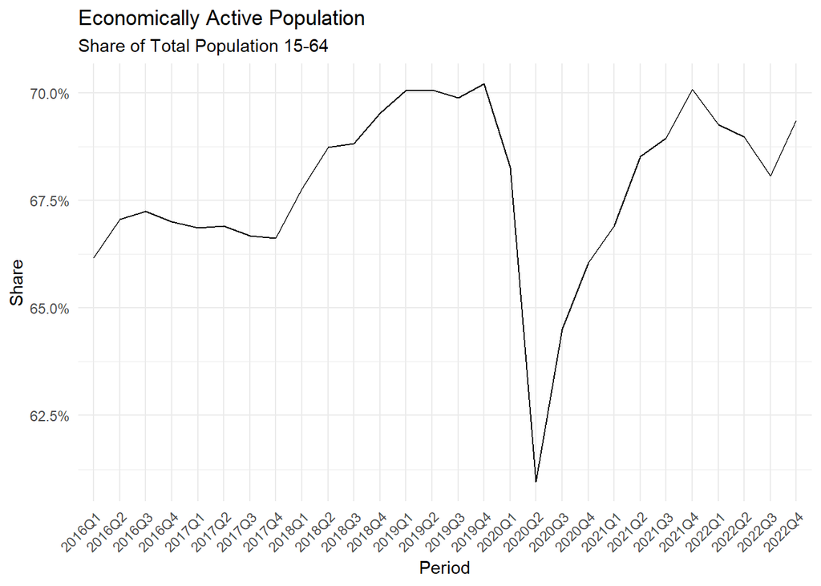

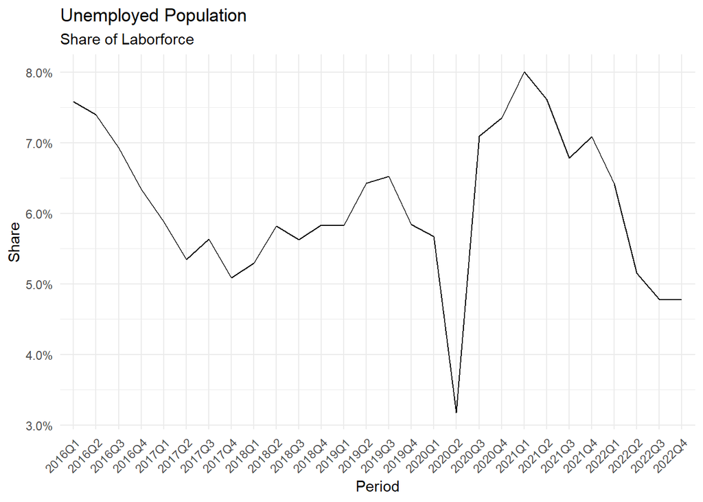

## Trends in Employment type

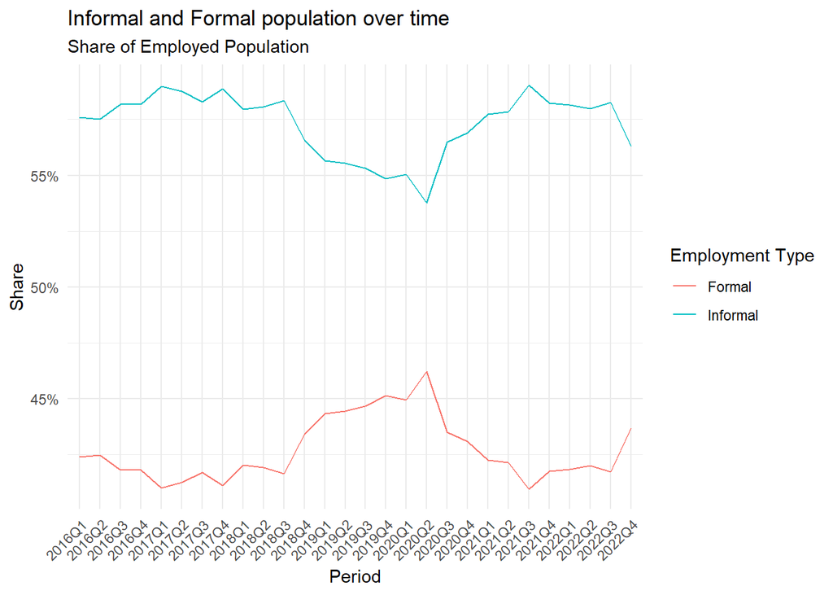

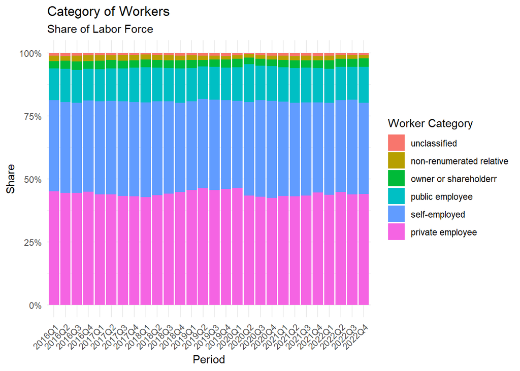

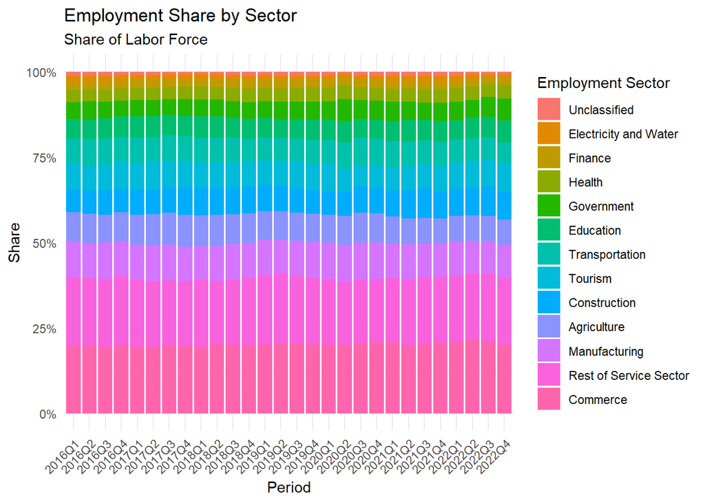

## Trends in Worker Traits and Outcomes

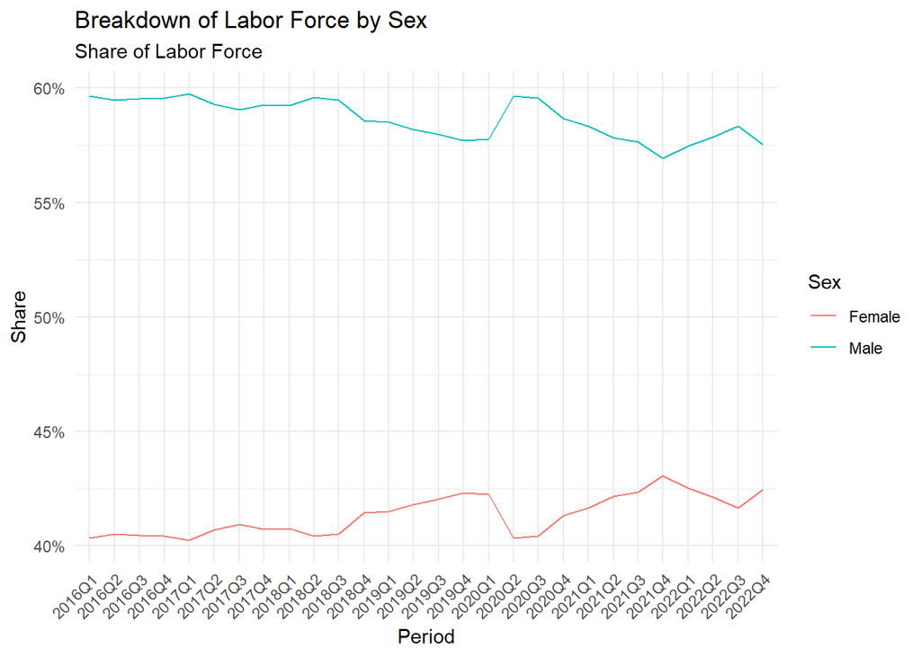

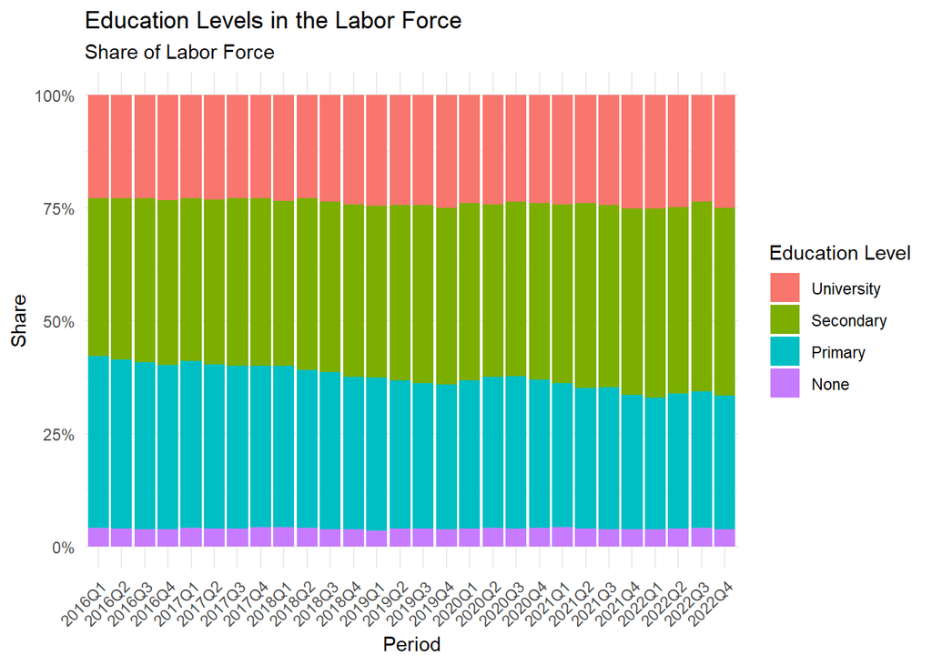

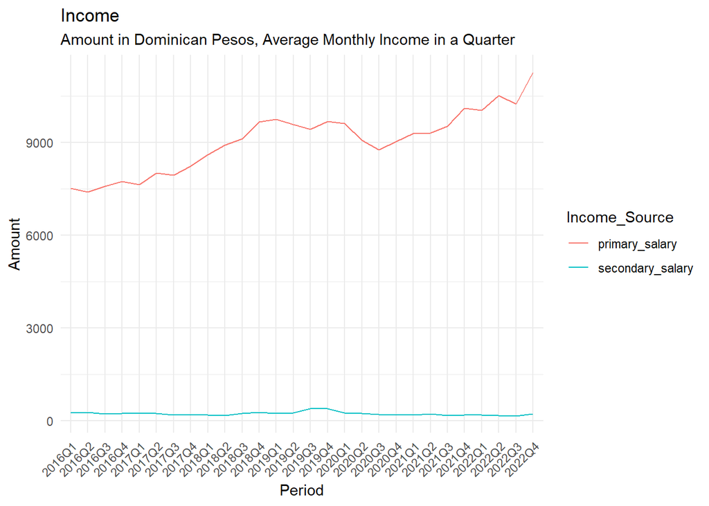

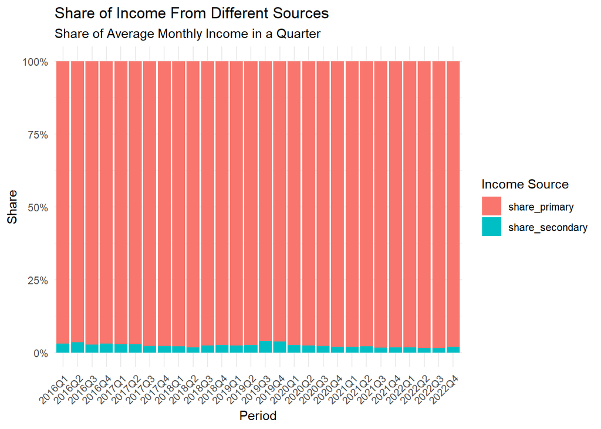

# Formal vs Informal sector

Comparing formal and informal sector we can see most workers with formal employment are classified as either private or public sector employees. In the informal sector there is are a significant number of private sector employees but the largest group is self employed which makes up a negligible amount of formal employment. Looking at economic sectors we see commerce and rest of services is a bit more dominant in the informal sector while the formal sector has a more even mix of sectors.

According to the survey men make up the majority of both types of workers but have even greater representation in the informal sector. Looking at education levels the formal sector workers have secondary or higher education for the most part while in the informal sector the majority have primary education although this share is falling and being replaced by workers with secondary education over time.

Income levels are much higher in the formal sector. Crucially it seems that there is very little growth of incomes over time in the informal sector while there is significant growth in the formal sector.

## Trends in Employment type

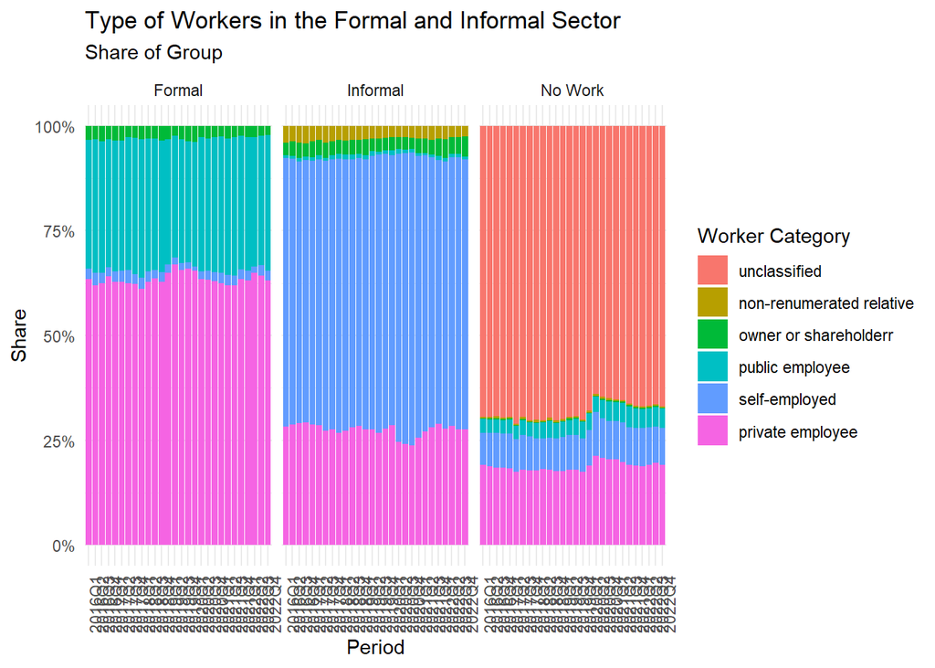

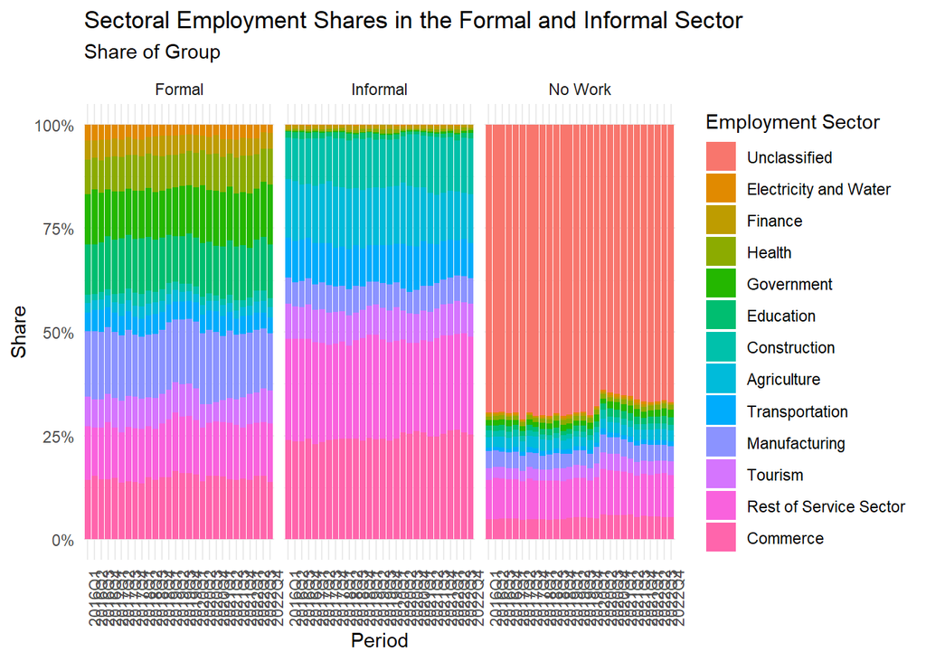

## Trends in Worker Traits and Outcomes

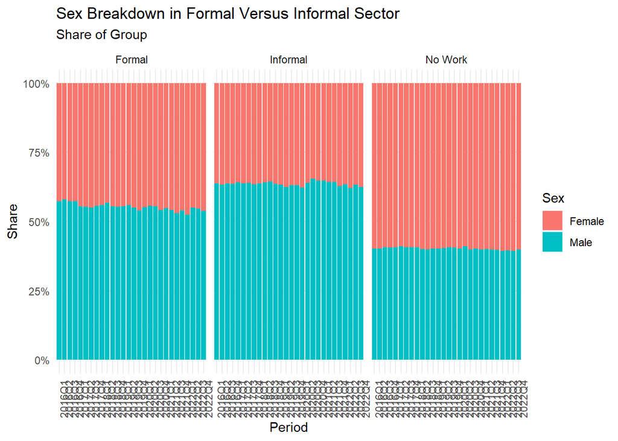

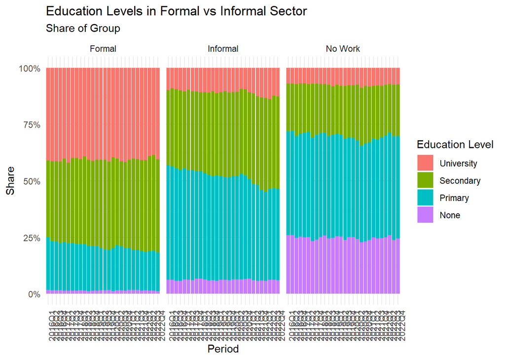

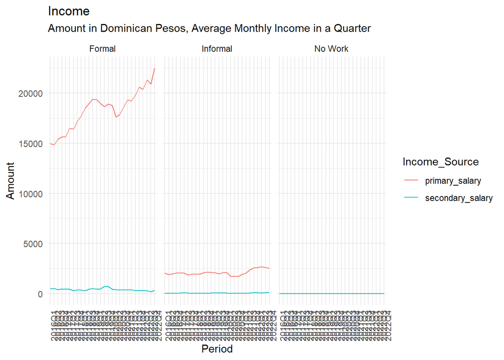

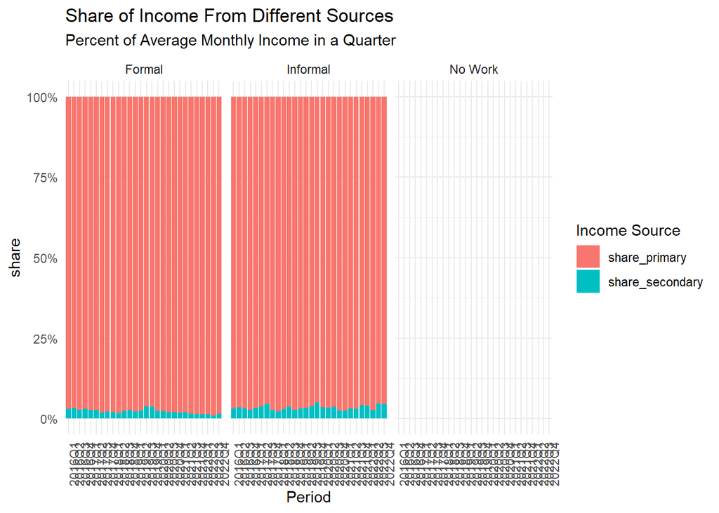

## Labor Force by Sex

Looking at the labor force in terms of Sex we see that men are dominate. The male participation rate is about 15% higher than the female participation rate and the unemployment rate is almost half for men compared to women in most years.

In terms of type of employment we can see again men have slightly more informal work and less formal work compared to women. We can also see that men have a higher share of people self employed while women have more employment that is unclassified in the survey. Sectorally the service sectors are a bit more dominate for women than men.

A higher share of women than men have university education and yet their salary is significantly lower than men on average. There seems to be a similar trend in salary increases for both groups.

## Macro Trends

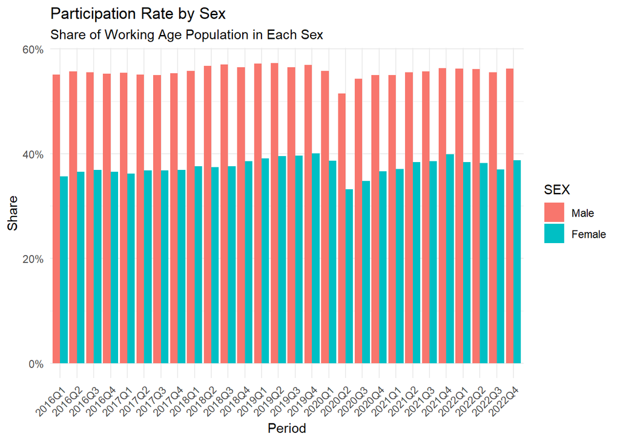

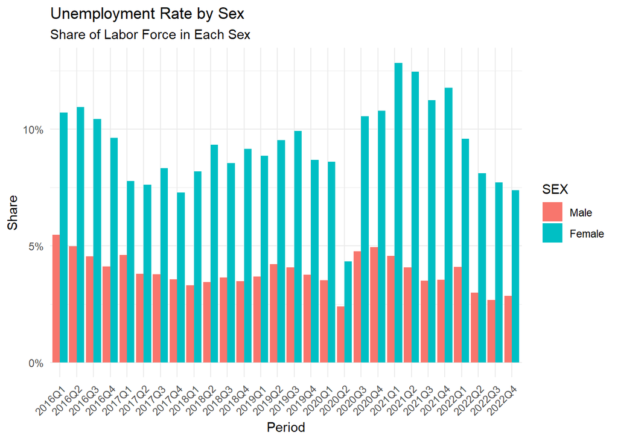

## Trends in Employment type

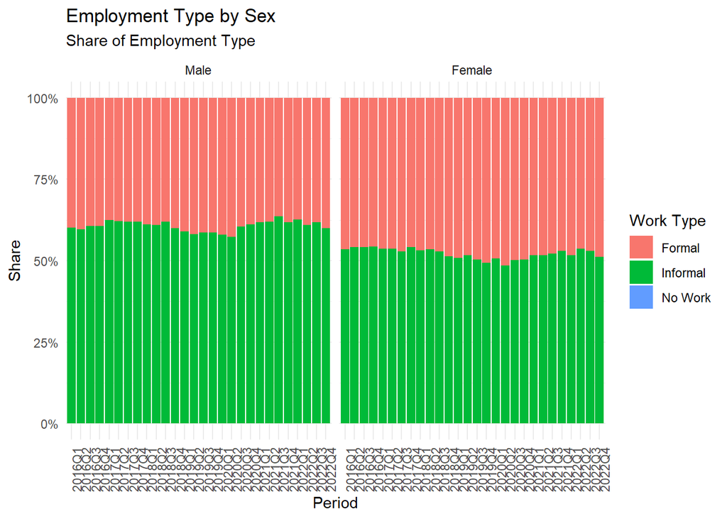

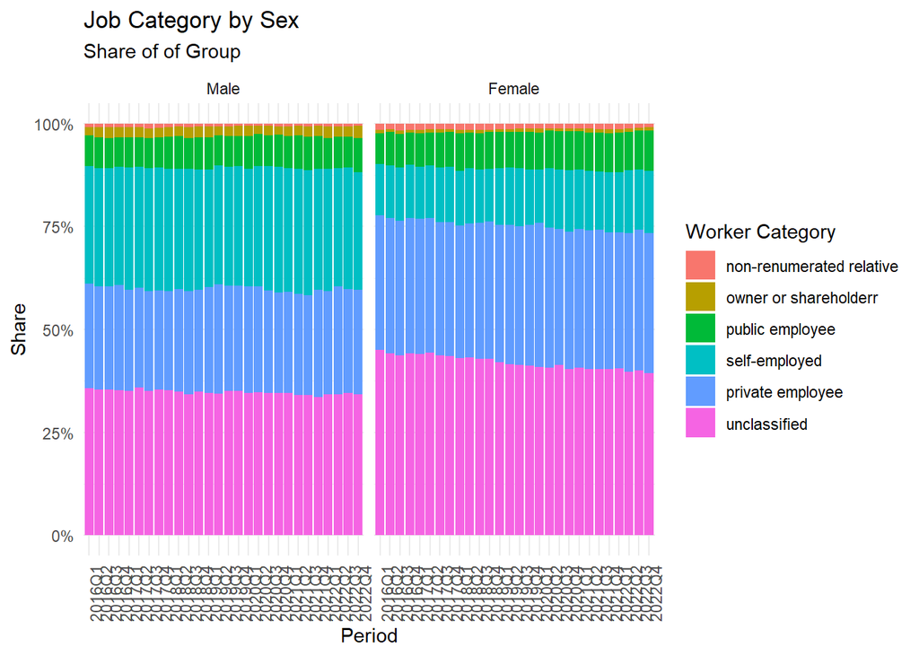

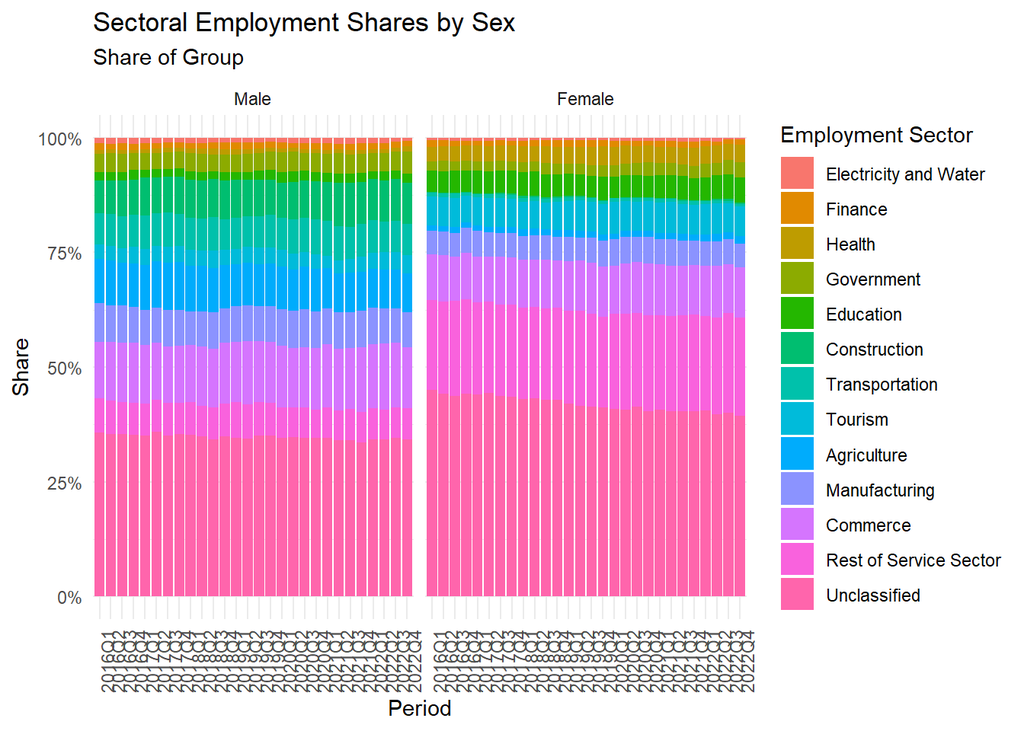

## Trends in Worker Traits and Outcomes

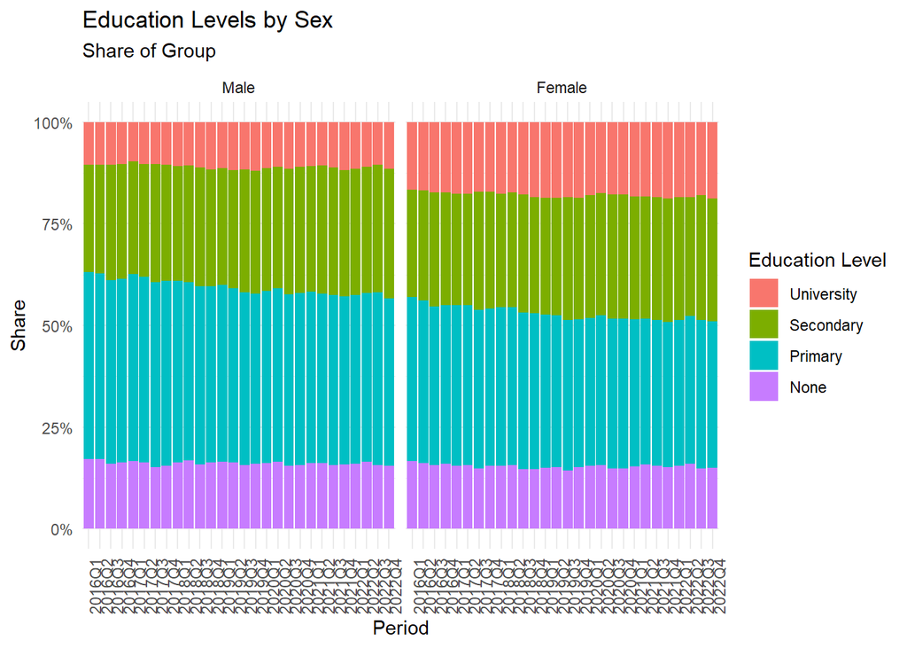

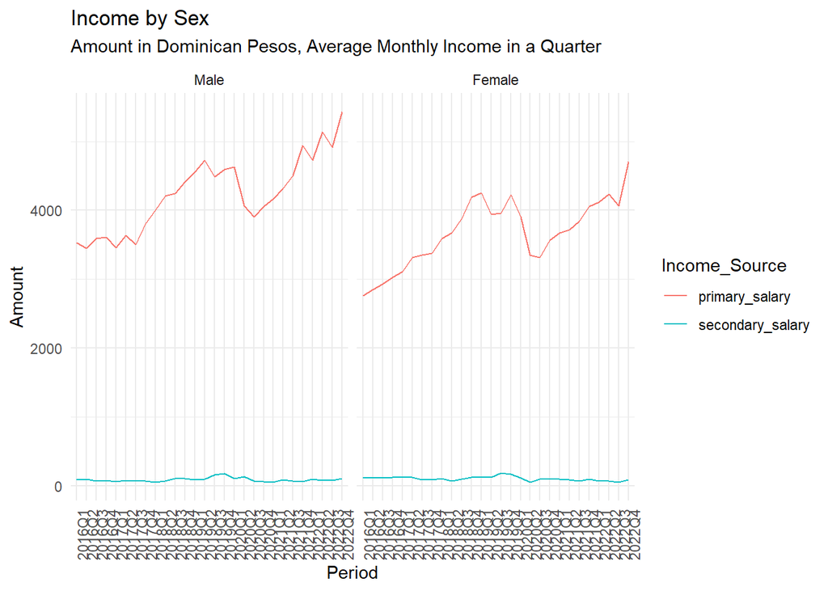

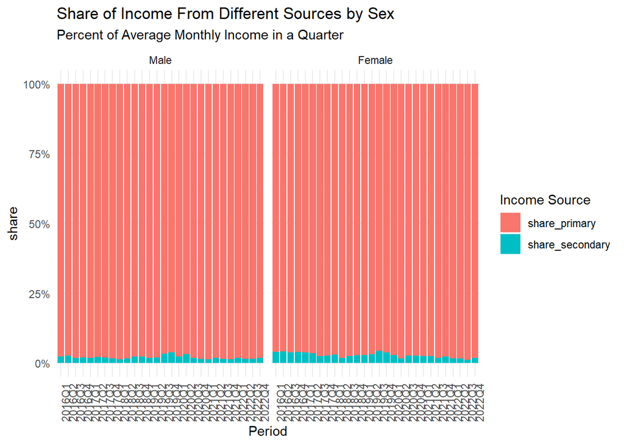

## Labor Force by Education Level

In terms of income there does appear to be significant income gains when going up the education ladder with university educated people reporting significantyl higher income than all other groups.

## Macro Trends

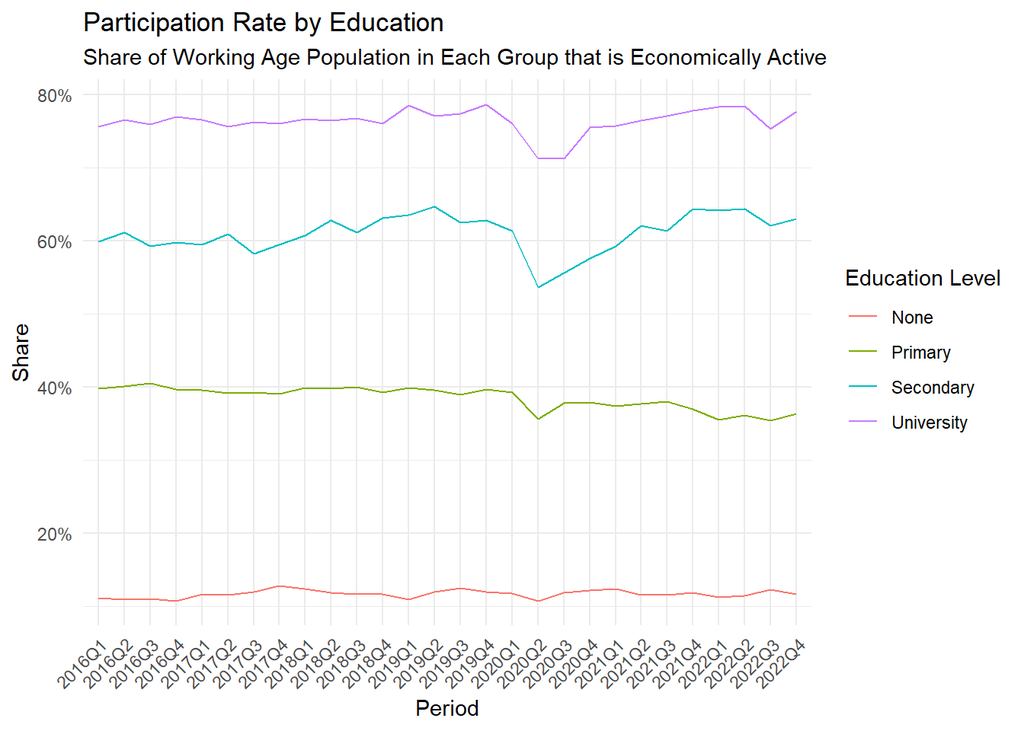

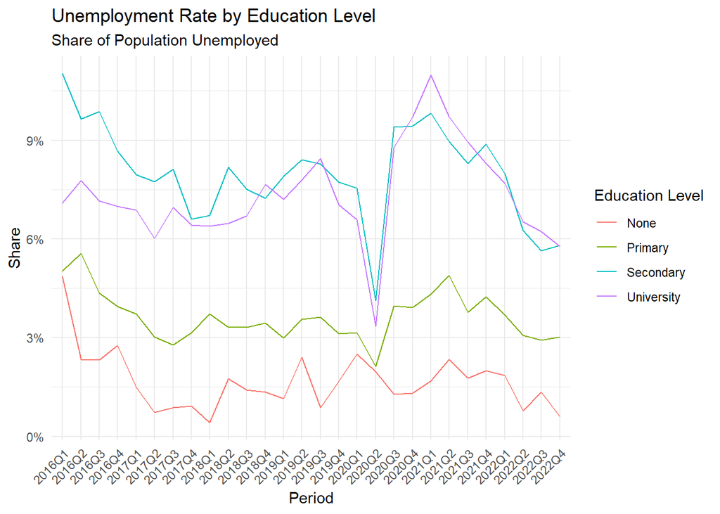

## Trends in Employment type

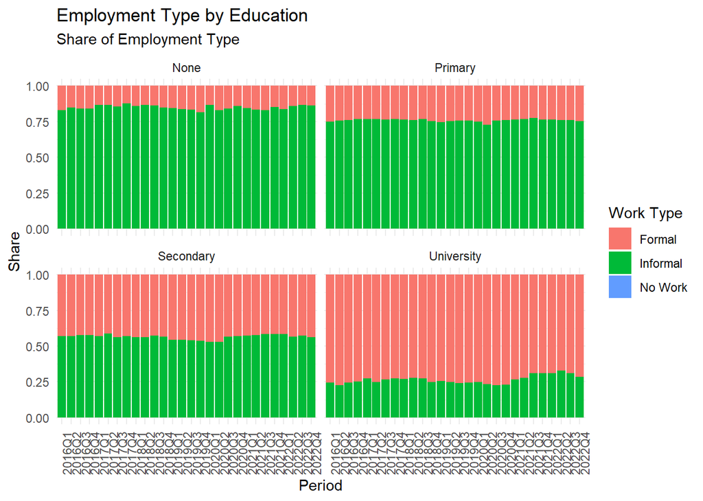

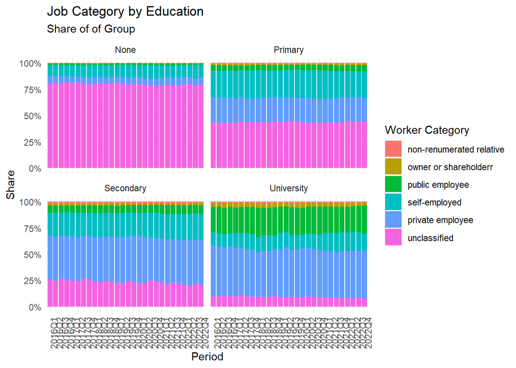

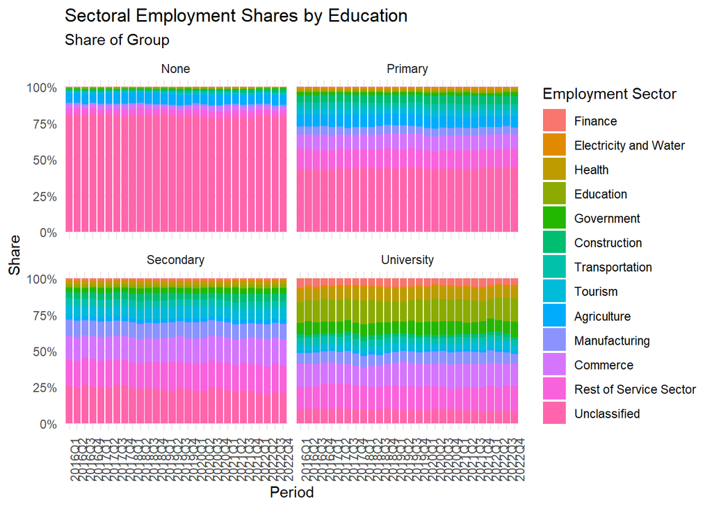

## Trends in Worker Traits and Outcomes

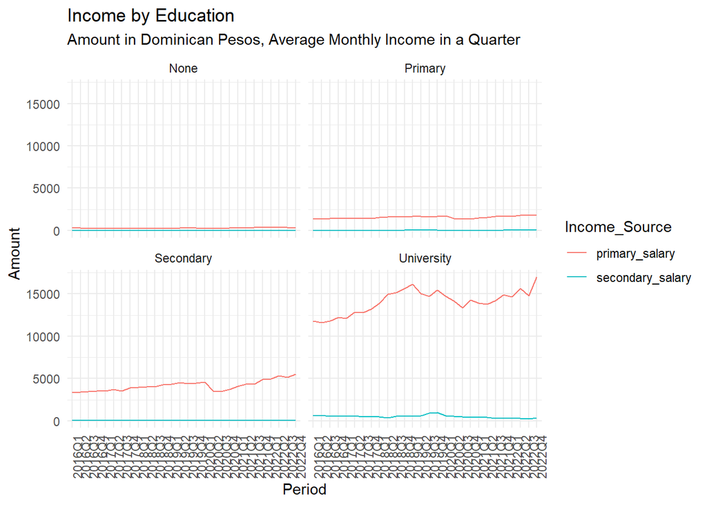

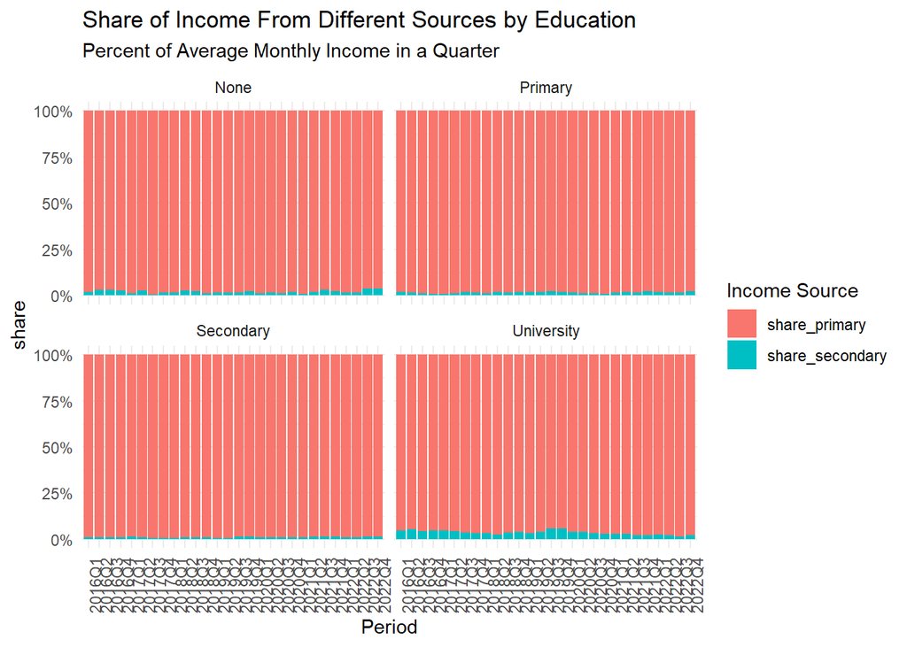